# Ever wonder why your R code is running slow?

February 28, 2018

## Using R interactively vs scripting

- Most users run interactively in console
- R scripts can be run as batch jobs
- Run in background or on cluster
- Useful when repeatedly running same code

## Why time?

- We've seen in previous meetings similar functions have different run times (`read.csv` vs `readr::read_csv`)
- If you do exploratory data analysis in the console, this isn't a big issue
- If you run the same code every day and it takes an hour, you may be able to save a lot of time
- Show it is competitive with other methods

## `microbenchmark` package

- Quickly compare code run times with high accuracy
- Arguments are expressions (Use {} for multi-line)

```r
library(microbenchmark)
# Calculate square root of 10,000 numbers
n <- 1e4
x <- runif(n)
microbenchmark(
  sqrt(x),
  x^0.5
)
```

```
## Unit: microseconds
##     expr     min      lq     mean   median      uq      max neval cld
##  sqrt(x)  77.547 102.825 156.8839 129.6245 146.541 2938.031   100  a
##    x^0.5 500.632 610.871 729.4560 688.4170 742.776 4291.298   100   b
```

## Cool plots, too

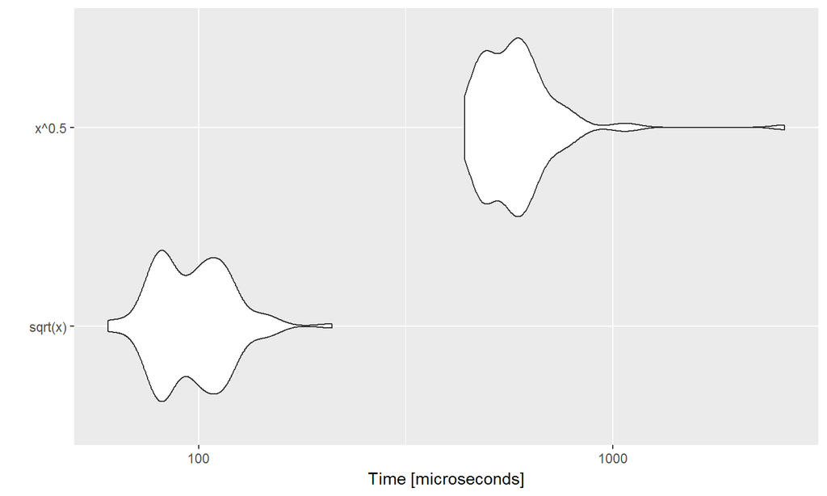

```r
ggplot2::autoplot(microbenchmark(sqrt(x), x^0.5))
```

## Are `for` loops slow?

```r
microbenchmark(sqrt = {t1 <- sqrt(x)},
               sapply = {t2 <-  sapply(x, sqrt)},
               forloop = {t3 <- numeric(n);
                 for (i in 1:length(x)) {
                   t3[i] <- sqrt(x[i])
                 }
               }
)
```

```
## Unit: microseconds
##     expr      min       lq      mean   median       uq       max neval cld
##     sqrt   56.259   66.903  108.5009   87.620  101.115  2068.672   100 a
##   sapply 3779.641 4736.621 5359.8529 5092.613 5453.167 14333.214   100   c
##  forloop 3573.230 4270.390 4801.3153 4568.984 5029.322 16170.007   100  b
```

## Are `for` loops slow?

- Not necessarily compared to `sapply`
- You should probably use `sapply` for clarity in most cases
- Always use vectorized functions when available
- Always preallocate memory when using `for` loops
  - i.e., don't append each iteration

## Are `for` loops slow?

```
## Unit: microseconds
##         expr        min         lq       mean     median         uq
##         sqrt     61.201     67.664     81.044     73.365     92.371
##       sapply   4027.486   4625.432   5104.245   5235.163   5315.750
##      forloop   4054.476   4495.808   4677.777   4722.746   4983.896
##   badforloop   6756.066   7184.093   7837.500   7885.055   8012.399
##  badforloop2 188826.966 191373.462 244356.026 218777.286 310290.941
##         max neval cld
##     115.940    10  a
##    6557.258    10  a
##    5238.964    10  a
##    9613.890    10  a
##  319117.579    10   b
```

## Example of aggregating data [(Source)](https://trinkerrstuff.wordpress.com/2012/04/28/microbenchmarking-with/)

```r
library(plyr)
op <- microbenchmark(
        PLYR=ddply(mtcars, .(cyl, gear), summarise,
          output = mean(hp)),
        AGGR=aggregate(hp ~ cyl + gear, mtcars, mean),
        TAPPLY = tapply(mtcars$hp, interaction(mtcars$cyl,
          mtcars$gear), mean),
      times=1000L)
print(op)
```

```
## Unit: microseconds
##    expr      min        lq      mean   median       uq      max neval cld
##    PLYR 2774.195 4331.7820 7424.8302 5487.379 7400.008 207838.5  1000   c
##    AGGR 1119.105 1805.8120 3264.3914 2187.463 2922.827 226317.4  1000  b
##  TAPPLY  358.463  588.4425  922.6606  710.655  889.697  35483.7  1000 a
```

## Example of aggregating data

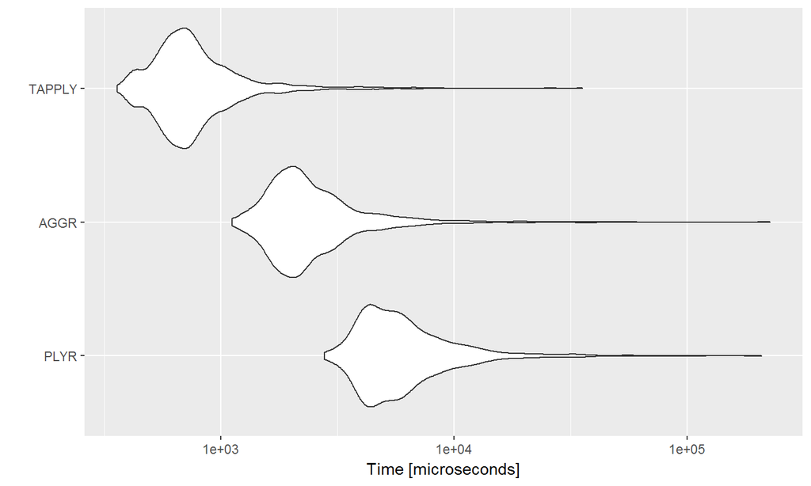

```r
ggplot2::autoplot(op)
```

## Summary of `microbenchmark`

- Quickly compare run times of code
- Precise timing
- Doesn't tell you why your code is slow

## `profvis`

- Shows how long is spent in each part of code
- Top section shows how long each line takes
- Bottom section shows where it is over the course of time
- The total time is given in bottom right corner

## `profvis` example [(source)](https://rstudio.github.io/profvis/)

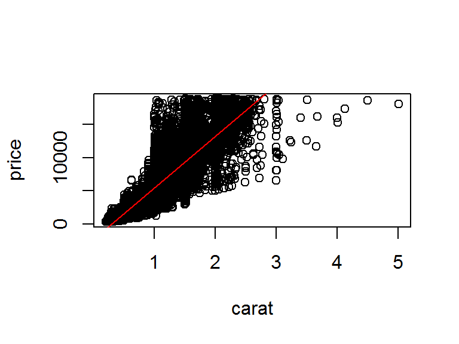

```r
library(profvis)
pv <- profvis({
  data(diamonds, package = "ggplot2")
  plot(price ~ carat, data = diamonds)
  m <- lm(price ~ carat, data = diamonds)
  abline(m, col = "red")
})
```

## `profvis` example

[interactive chart not shown]

## `profvis` of [Adam's code](http://rpubs.com/angoodkind/352340) from last meeting

```
## # A tibble: 87 x 13
##    name     height  mass hair_color skin_color eye_color birth_year gender
##    <chr>     <int> <dbl> <chr>      <chr>      <chr>          <dbl> <chr>
##  1 Luke Sk~    172  77.0 blond      fair       blue            19.0 male
##  2 C-3PO       167  75.0 <NA>       gold       yellow         112   <NA>
##  3 R2-D2        96  32.0 <NA>       white, bl~ red             33.0 <NA>
##  4 Darth V~    202 136   none       white      yellow          41.9 male
##  5 Leia Or~    150  49.0 brown      light      brown           19.0 female
##  6 Owen La~    178 120   brown, gr~ light      blue            52.0 male
##  7 Beru Wh~    165  75.0 brown      light      blue            47.0 female
##  8 R5-D4        97  32.0 <NA>       white, red red             NA   <NA>
##  9 Biggs D~    183  84.0 black      light      brown           24.0 male
## 10 Obi-Wan~    182  77.0 auburn, w~ fair       blue-gray       57.0 male
## # ... with 77 more rows, and 5 more variables: homeworld <chr>,
## #   species <chr>, films <list>, vehicles <list>, starships <list>
```

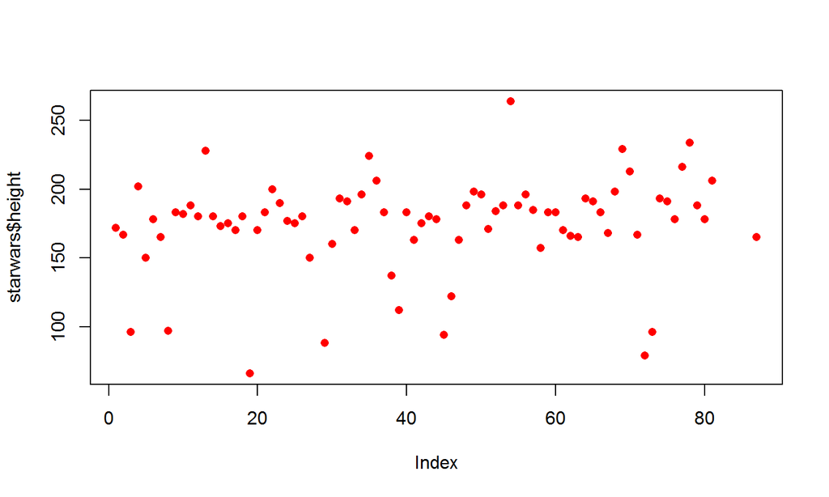

```r
pv_adam <- profvis::profvis({
  # install.packages(c("tidyverse", "magrittr"))
  library(tidyverse)
  # data()
  starwars
  print(starwars)
  # str(starwars)
  head(starwars)
  sum(1:8) %>%
    sqrt()
  starwars %>% filter(height < 90)
  starwars %>%
    filter(height < 90) %>%
    select(name, gender, species, height)
  starwars %>% filter(eye_color == "red") %>% select(name)
  filter(starwars, height < 90) %>%
    select(name, gender, species, height) %>%
    arrange(height)
  starwars %>% arrange(name)
  starwars %>%
    na.omit() %>%
    group_by(species) %>%
    summarize(avg_mass = mean(mass))
  starwars %>%
    na.omit() %>%
    group_by(species, gender) %>%
    select(name, gender, species, mass) %>%
    mutate(avg_mass = mean(mass))
  starwars %>%
    mutate(height_plus_mass = height + mass) %>%
    select(name, height, mass, height_plus_mass)
  nums <- c(0.7, 1.2, 3.4)
  factor_nums <- as.factor(nums)
  levels(factor_nums)
  nums+1
  factor_nums+1
  # Base R
  plot(starwars$height, type='p', col='red', pch=16)
  ggplot(data=starwars, aes(x=height, y=mass)) + geom_point() + geom_boxplot()
  ggplot(starwars, aes(x=height, y=mass)) +
    geom_point(aes(color=gender), size=5)
  ggplot(subset(starwars, species %in% c('Droid', 'Human', "Gungan")),
         aes(x=species, y=height)) +
    geom_boxplot()
  ggplot(starwars, aes(x=height, y=mass)) +
    geom_point(size=5) +
    stat_smooth(method='lm')
  starwars %>%
    filter(species == 'Human' & gender %in% c('male', 'female')) %>%
    ggplot(aes(mass)) +
    geom_histogram() +
    facet_grid(. ~ gender)
  starwars %>%
    filter(homeworld %in% c("Naboo", "Tatooine")) %>%
    ggplot(aes(species)) +
    geom_bar() +
    facet_grid(. ~ homeworld)
})
```

## `profvis` of [Adam's code](http://rpubs.com/angoodkind/352340) from January

[interactive chart not shown]

## Beware: premature optimization

- "Programmers waste enormous amounts of time thinking about, or worrying about, the speed of noncritical parts of their programs, and these attempts at efficiency actually have a strong negative impact when debugging and maintenance are considered. We should forget about small efficiencies, say about 97% of the time: **premature optimization is the root of all evil**. Yet we should not pass up our opportunities in that critical 3%." - Don Knuth
- Don't spend hours to save minutes

## How to speed up your code

- Vectorize and preallocate
- Find faster functions, e.g. `readr::read_csv` instead of `read.csv`
- Store data instead of recreating
- Reformulate to reduce time in slow parts
- Convert slow parts to C++ code with Rcpp
- Parallelize

## Examples where `profvis` helped me

- Slow matrix multiplication when I only needed diagonal
  - `diag(A%*%B) = colSums(t(A)*B)`
- Recalculated same matrix thousands of times
  - Reorganize functions to share calculation
- Slow function that is repeatedly used
  - Write in Rcpp (C++)

## How I use `profvis`

- Occasionally use `profvis` to find bottlenecks
- See if there's a simple fix
  - e.g., don't calculate full matrix if only need diagonal
- If still bottleneck, use Rcpp

## Conclusion

- Use `microbenchmark` to accurately time code
- Use `profvis` to find where code is slow
- Speed up code by using faster functions, writing more efficient code
- Don't waste time trying to speed up code

## Sources

- https://www.r-bloggers.com/using-the-microbenchmark-package-to-compare-the-execution-time-of-r-expressions/
- https://rstudio.github.io/profvis/
- http://adv-r.had.co.nz/Performance.html#microbenchmarking
- https://trinkerrstuff.wordpress.com/2012/04/28/microbenchmarking-with/
- https://www.analyticsvidhya.com/blog/2017/09/creating-visualizing-neural-network-in-r/
- http://rpubs.com/angoodkind/352340